# Quant Assignment 3

Aron Lesser

9/22/2020

# Loading Data

I begin by loading the data and filtering income to be greater than 0. I also altered the ethnicity category to only include Hispanic/Not Hispanic.

```r
new_person_data <- read_csv("people.csv")%>%
   filter(PINCP > 0)%>%
  mutate(HISP_label = case_when(
    HISP_label == "Not Spanish/Hispanic/Latino" ~ "Non Hispanic",
    HISP_label ==                          "Dominican" ~ "Hispanic",
    HISP_label ==                          "Guatemalan" ~ "Hispanic",
    HISP_label ==                          "Mexican" ~ "Hispanic",
    HISP_label ==                          "Salvadoran" ~ "Hispanic",
    HISP_label ==                          "Ecuadorian" ~ "Hispanic",
    HISP_label ==                          "Puerto Rican" ~ "Hispanic",
    HISP_label ==                          "All Other Spanish/Hispanic/Latino" ~ "Hispanic",
    HISP_label ==                          "Colombian" ~ "Hispanic",
    HISP_label ==                          "Panamanian" ~ "Hispanic",
    HISP_label ==                          "Cuban" ~ "Hispanic",
    HISP_label ==                          "Honduran" ~ "Hispanic",
    HISP_label ==                          "Peruvian" ~ "Hispanic",
    HISP_label ==                          "Spaniard" ~ "Hispanic",
    HISP_label ==                          "Venezuelan" ~ "Hispanic",
    HISP_label ==                          "Uruguayan" ~ "Hispanic",
    HISP_label ==                          "Nicaraguan" ~ "Hispanic",
    HISP_label ==                          "Costa Rican" ~ "Hispanic",
    HISP_label ==                          "Other Central American" ~ "Hispanic",
    HISP_label ==                          "Argentinean" ~ "Hispanic",
    HISP_label ==                          "Chilean" ~ "Hispanic",
    HISP_label ==                          "Paraguayan" ~ "Hispanic",
    HISP_label ==                          "Other South American" ~ "Hispanic"))
  attach(new_person_data)
```

# Variables

For this assignment, I will use 5 variables:

*Categorical*

1. **HISP**: Altered to include only Hispanic and Non-Hispanic
2. **MIG**: Mobility status (lived here 1 year ago)

*Continuous*

3. **PINCP**: Income
4. **NP**: Number of persons in this household
5. **RNTP**: Monthly rent

# Relationships Between Two Continuous Variables

## Correlation between Income and Rent

```r
correlation <- cor.test(new_person_data$PINCP, new_person_data$RNTP)

correlation
```

```
##
##  Pearson's product-moment correlation
##
## data:  new_person_data$PINCP and new_person_data$RNTP
## t = 41.212, df = 17075, p-value < 2.2e-16
## alternative hypothesis: true correlation is not equal to 0
## 95 percent confidence interval:
##  0.2870778 0.3143616
## sample estimates:
##       cor
## 0.3007813
```

I was expecting to see a stronger correlation betweeen income and rent, which is only .3

### Plotting Income and Rent

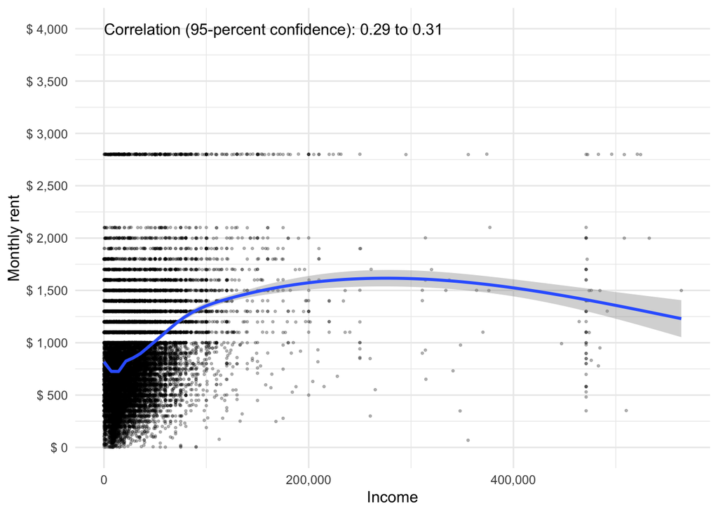

```r
ggplot(new_person_data, aes(x = PINCP, y = RNTP)) +
  geom_point(size = 0.5, alpha = 0.25, position = "jitter") +
  geom_smooth() +
  theme_minimal() +
  scale_x_continuous(name = "Income", label = comma) +
  scale_y_continuous(name = "Monthly rent",
                     breaks = seq(0, 4000, by = 500),
                     labels = paste("$",
                                    prettyNum(seq(0, 4000, by = 500),
                                              big.mark = ","))) +
  annotate(geom = "text", x = 0, y = 4000,
           label = paste("Correlation (95-percent confidence):",
                         prettyNum(correlation$conf.int[1], digits = 2),
                         "to",
                         prettyNum(correlation$conf.int[2], digits = 2)),
           hjust = 0)
```

### Testing Income and Rent at a max income of $100,000

It appeared that there may be a slightly different correlation strength among people in the sample that earn $100,000 or less. I created a new dataset to test this hypothesis.

```r
new_person_data_1 <- read_csv("people.csv") %>%
   filter(PINCP > 0, PINCP < 100000) %>%
  mutate(HISP_label = case_when(
    HISP_label == "Not Spanish/Hispanic/Latino" ~ "Non Hispanic",
    HISP_label ==                          "Dominican" ~ "Hispanic",
    HISP_label ==                          "Guatemalan" ~ "Hispanic",
    HISP_label ==                          "Mexican" ~ "Hispanic",
    HISP_label ==                          "Salvadoran" ~ "Hispanic",
    HISP_label ==                          "Ecuadorian" ~ "Hispanic",
    HISP_label ==                          "Puerto Rican" ~ "Hispanic",
    HISP_label ==                          "All Other Spanish/Hispanic/Latino" ~ "Hispanic",
    HISP_label ==                          "Colombian" ~ "Hispanic",
    HISP_label ==                          "Panamanian" ~ "Hispanic",
    HISP_label ==                          "Cuban" ~ "Hispanic",
    HISP_label ==                          "Honduran" ~ "Hispanic",
    HISP_label ==                          "Peruvian" ~ "Hispanic",
    HISP_label ==                          "Spaniard" ~ "Hispanic",
    HISP_label ==                          "Venezuelan" ~ "Hispanic",
    HISP_label ==                          "Uruguayan" ~ "Hispanic",
    HISP_label ==                          "Nicaraguan" ~ "Hispanic",
    HISP_label ==                          "Costa Rican" ~ "Hispanic",
    HISP_label ==                          "Other Central American" ~ "Hispanic",
    HISP_label ==                          "Argentinean" ~ "Hispanic",
    HISP_label ==                          "Chilean" ~ "Hispanic",
    HISP_label ==                          "Paraguayan" ~ "Hispanic",
    HISP_label ==                          "Other South American" ~ "Hispanic"))
  attach(new_person_data_1)
```

### Correlation between 100k income and rent

As it turns out, it is not significantly different than above. I will need to think about some possible explanations. It is clear that there are more renters in lower income brackets.

```r
correlation <- cor.test(new_person_data_1$PINCP, new_person_data_1$RNTP)

correlation
```

```
##
##  Pearson's product-moment correlation
##
## data:  new_person_data_1$PINCP and new_person_data_1$RNTP
## t = 39.647, df = 16431, p-value < 2.2e-16
## alternative hypothesis: true correlation is not equal to 0
## 95 percent confidence interval:
##  0.2814697 0.3093794
## sample estimates:
##       cor
## 0.2954876
```

### Plotting 100k Income and Rent

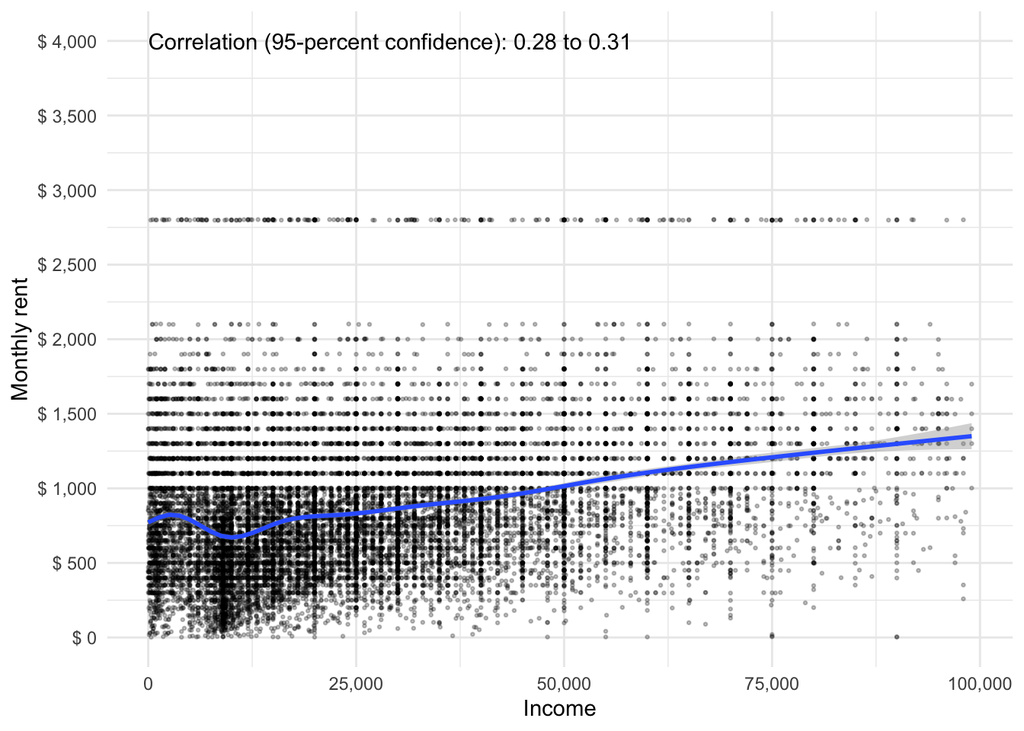

```r
ggplot(new_person_data_1, aes(x = PINCP, y = RNTP)) +
  geom_point(size = 0.5, alpha = 0.25, position = "jitter") +
  geom_smooth() +
  theme_minimal() +
  scale_x_continuous(name = "Income", label = comma) +
  scale_y_continuous(name = "Monthly rent",
                     breaks = seq(0, 4000, by = 500),
                     labels = paste("$",
                                    prettyNum(seq(0, 4000, by = 500),
                                              big.mark = ","))) +
  annotate(geom = "text", x = 0, y = 4000,
           label = paste("Correlation (95-percent confidence):",
                         prettyNum(correlation$conf.int[1], digits = 2),
                         "to",
                         prettyNum(correlation$conf.int[2], digits = 2)),
           hjust = 0)
```

## Correlation between Household Size and Rent

```r
correlation <- cor.test(new_person_data$NP, new_person_data$RNTP)

correlation
```

```
##
##  Pearson's product-moment correlation
##
## data:  new_person_data$NP and new_person_data$RNTP
## t = 17.722, df = 17075, p-value < 2.2e-16
## alternative hypothesis: true correlation is not equal to 0
## 95 percent confidence interval:
##  0.1196344 0.1490897
## sample estimates:
##       cor
## 0.1343918
```

There is an extremely modest correlation between household size and monthly rent.

### Plotting Household Size and Rent

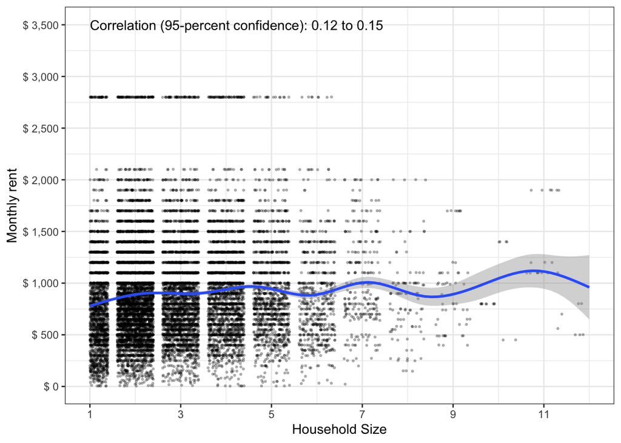

```r
ggplot(new_person_data, aes(x = NP, y = RNTP)) +
  geom_point(size = 0.5, alpha = 0.25, position = "jitter") +
  geom_smooth() +
  theme_bw() +
  scale_x_continuous(name = "Household Size", limits = c(1,12), seq(1, 12, by = 2)) +
  scale_y_continuous(name = "Monthly rent",
                     breaks = seq(0, 4000, by = 500),
                     labels = paste("$",
                                    prettyNum(seq(0, 4000, by = 500),
                                              big.mark = ","))) +
  annotate(geom = "text", x = 1, y = 3500,
           label = paste("Correlation (95-percent confidence):",
                         prettyNum(correlation$conf.int[1], digits = 2),
                         "to",
                         prettyNum(correlation$conf.int[2], digits = 2)),
           hjust = 0)
```

## Correlation between Household Size and Income

```r
correlation <- cor.test(new_person_data$NP, new_person_data$PINCP)

correlation
```

```
##
##  Pearson's product-moment correlation
##
## data:  new_person_data$NP and new_person_data$PINCP
## t = -11.043, df = 17075, p-value < 2.2e-16
## alternative hypothesis: true correlation is not equal to 0
## 95 percent confidence interval:
##  -0.09908143 -0.06929708
## sample estimates:
##         cor
## -0.08420806
```

This is again an interesting case in which there seems to be a very weak correlation between household size and income.

### Plotting Household Size and Income

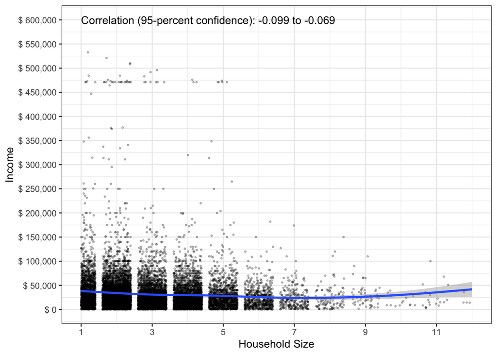

```r
options(scipen=999)

ggplot(new_person_data, aes(x = NP, y = PINCP)) +
  geom_point(size = 0.5, alpha = 0.25, position = "jitter") +
  geom_smooth() +
  theme_bw() +
  scale_x_continuous(name = "Household Size", limits = c(1,12), seq(1, 12, by = 2)) +
  scale_y_continuous(name = "Income",
                     breaks = seq(0, 600000, by = 50000),
                     labels = paste("$",
                                    prettyNum(seq(0, 600000, by = 50000),
                                              big.mark = ","))) +
  annotate(geom = "text", x = 1, y = 600000,
           label = paste("Correlation (95-percent confidence):",
                         prettyNum(correlation$conf.int[1], digits = 2),
                         "to",
                         prettyNum(correlation$conf.int[2], digits = 2)),
           hjust = 0)
```

# Relationships between a Continuous Variable and a Binary Categorical One - Ethnicity

## Ethnicity and Income

```r
difference = t.test(PINCP ~ HISP_label == "Hispanic",
                    data = new_person_data)

difference
```

```
##
##  Welch Two Sample t-test
##
## data:  PINCP by HISP_label == "Hispanic"
## t = 4.2997, df = 2366.6, p-value = 0.00001779
## alternative hypothesis: true difference in means is not equal to 0
## 95 percent confidence interval:
##  1983.509 5309.696
## sample estimates:
## mean in group FALSE  mean in group TRUE
##            33123.45            29476.85
```

### Plotting Ethnicity and Income

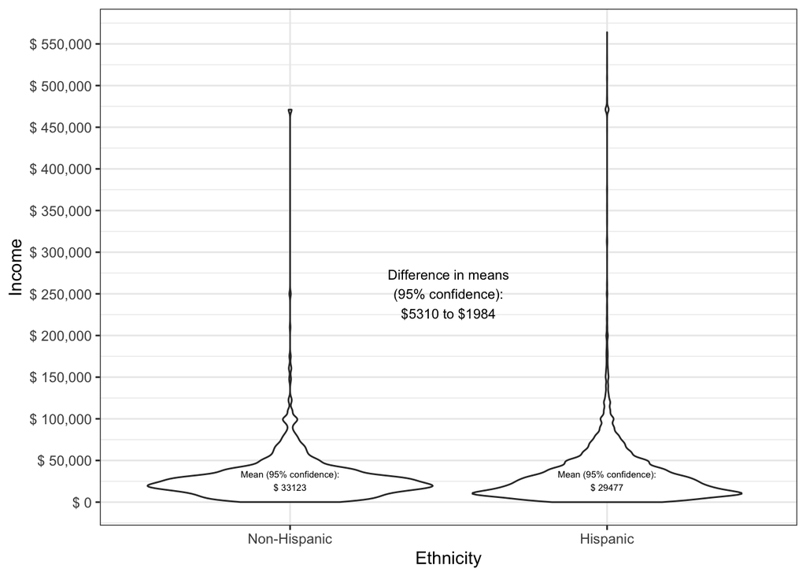

```r
options(scipen=999)

ggplot(new_person_data, aes(x = HISP_label, y = PINCP)) +
  geom_violin() +
  theme_bw() +
  scale_x_discrete(name = "Ethnicity",
                   labels = c("Non-Hispanic", "Hispanic")) +
   scale_y_continuous(name = "Income",
                     breaks = seq(0, 600000, by = 50000),
                     labels = paste("$",
                                    prettyNum(seq(0, 600000, by = 50000),
                                              big.mark = ","))) +
  annotate(geom = "text", x = 1.5, y = 250000, size = 3,
           label = paste("Difference in means\n(95% confidence):\n$",
                         prettyNum(abs(difference$conf.int[2]),
                                   digits = 0), " to $",
                         prettyNum(abs(difference$conf.int[1]),
                                   digits = 0),
                         sep = "")) +
  annotate(geom = "text", x = 1, y = 26000, size = 2,
           label = paste("Mean (95% confidence):\n$",
                         prettyNum(difference$estimate[1], digits = 0))) +
  annotate(geom = "text", x = 2, y = 26000, size = 2,
           label = paste("Mean (95% confidence):\n$",
                         prettyNum(difference$estimate[2], digits = 0)))
```

## Ethnicity and Rent

```r
difference = t.test(RNTP ~ HISP_label == "Hispanic",
                    data = new_person_data)

difference
```

```
##
##  Welch Two Sample t-test
##
## data:  RNTP by HISP_label == "Hispanic"
## t = -6.5693, df = 2299.7, p-value = 0.00000000006231
## alternative hypothesis: true difference in means is not equal to 0
## 95 percent confidence interval:
##  -91.32606 -49.33691
## sample estimates:
## mean in group FALSE  mean in group TRUE
##            875.1887            945.5202
```

### Plotting Ethnicity and Rent

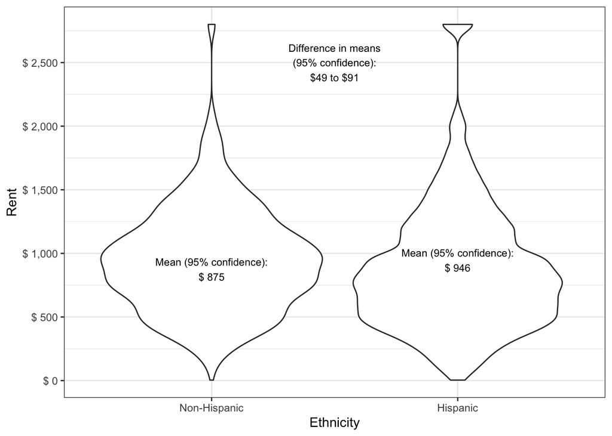

```r
ggplot(new_person_data, aes(x = HISP_label, y = RNTP)) +
  geom_violin() +
  theme_bw() +
  scale_x_discrete(name = "Ethnicity",
                   labels = c("Non-Hispanic", "Hispanic")) +
   scale_y_continuous(name = "Rent",
                     breaks = seq(0, 4000, by = 500),
                     labels = paste("$",
                                    prettyNum(seq(0, 4000, by = 500),
                                              big.mark = ","))) +
  annotate(geom = "text", x = 1.5, y = 2500, size = 3,
           label = paste("Difference in means\n(95% confidence):\n$",
                         prettyNum(abs(difference$conf.int[2]),
                                   digits = 0), " to $",
                         prettyNum(abs(difference$conf.int[1]),
                                   digits = 0),
                         sep = "")) +
  annotate(geom = "text", x = 1, y = difference$estimate[1], size = 3,
           label = paste("Mean (95% confidence):\n$",
                         prettyNum(difference$estimate[1], digits = 0))) +
  annotate(geom = "text", x = 2, y = difference$estimate[2], size = 3,
           label = paste("Mean (95% confidence):\n$",
                         prettyNum(difference$estimate[2], digits = 0)))
```

## Ethnicity and Household Size

```r
difference = t.test(NP ~ HISP_label == "Hispanic",
                    data = new_person_data)

difference
```

```
##
##  Welch Two Sample t-test
##
## data:  NP by HISP_label == "Hispanic"
## t = -19.84, df = 2024.7, p-value < 0.00000000000000022
## alternative hypothesis: true difference in means is not equal to 0
## 95 percent confidence interval:
##  -1.0247608 -0.8403915
## sample estimates:
## mean in group FALSE  mean in group TRUE
##            2.695862            3.628438
```

It appears that there is a statistically significant relationship between ethnicity and household size. In this case, Hispanics households are on average 1 person greater than their non-Hispanic counterparts.

### Plotting Ethnicity and Household Size

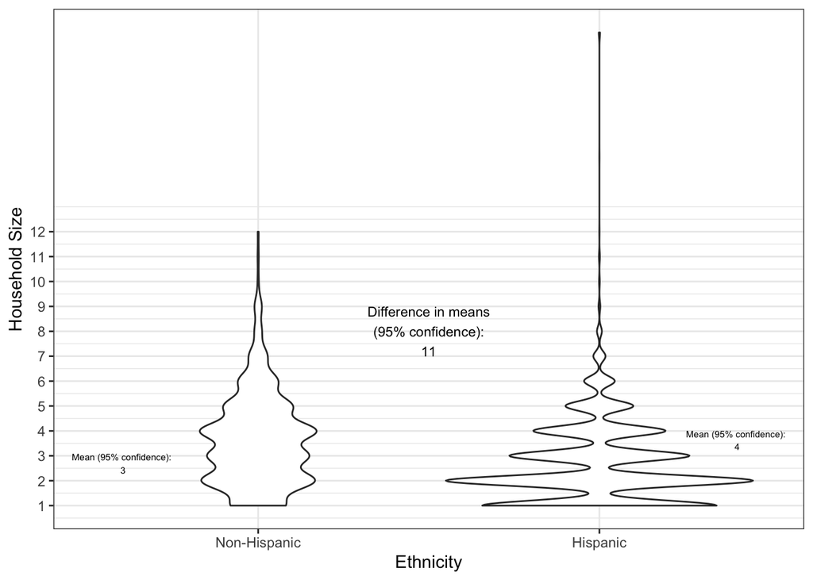

```r
ggplot(new_person_data, aes(x = HISP_label, y = NP)) +
  geom_violin() +
  theme_bw() +
  scale_x_discrete(name = "Ethnicity",
                   labels = c("Non-Hispanic", "Hispanic")) +
   scale_y_continuous(name = "Household Size",
                     breaks = seq(1, 12, by = 1),
                     labels = paste(
                                    prettyNum(seq(1, 12, by = 1),
                                              big.mark = ","))) +
  annotate(geom = "text", x = 1.5, y = 8, size = 3,
           label = paste("Difference in means\n(95% confidence):\n",
                         prettyNum(abs(difference$conf.int[2]),
                                   digits = 0),
                         prettyNum(abs(difference$conf.int[1]),
                                   digits = 0),
                         sep = "")) +
  annotate(geom = "text", x = .6, y = difference$estimate[1], size = 2,
           label = paste("Mean (95% confidence):\n",
                         prettyNum(difference$estimate[1], digits = 0))) +
  annotate(geom = "text", x = 2.4, y = difference$estimate[2], size = 2,
           label = paste("Mean (95% confidence):\n",
                         prettyNum(difference$estimate[2], digits = 0)))
```

# Relationships between a Continuous Variable and a Non-Binary Categorical One - Mobility Status

## Anova Mobility Status and Rent

```r
anova <- aov(RNTP ~ MIG_label, data = new_person_data)

summary(anova)
```

```
##                Df     Sum Sq  Mean Sq F value              Pr(>F)
## MIG_label       2   80509137 40254569   172.3 <0.0000000000000002 ***
## Residuals   17074 3989608349   233666
## ---
## Signif. codes:  0 '***' 0.001 '**' 0.01 '*' 0.05 '.' 0.1 ' ' 1
```

There appears to be a statistically significant relationship between the variables.

### Tukey’s Honestly Significant Difference - Mobility Status and Rent

```r
differences <- TukeyHSD(anova)

as_tibble(cbind(pair = row.names(differences$MIG_label),
                differences$MIG_label))
```

```
## # A tibble: 3 x 5
##   pair                             diff       lwr        upr       `p adj`
##   <chr>                            <chr>      <chr>      <chr>     <chr>
## 1 No, outside US and Puerto Rico-… 195.36571… 101.28887… 289.4425… 0.0000034399…
## 2 Yes, same house (nonmovers)-No,… -143.4979… -163.3635… -123.632… 0.0000000316…
## 3 Yes, same house (nonmovers)-No,… -338.8636… -431.9262… -245.801… 0.0000000316…
```

### Plotting Mobility Status and Rent

In this case, I found a boxplot to be more effective than a violin plot.

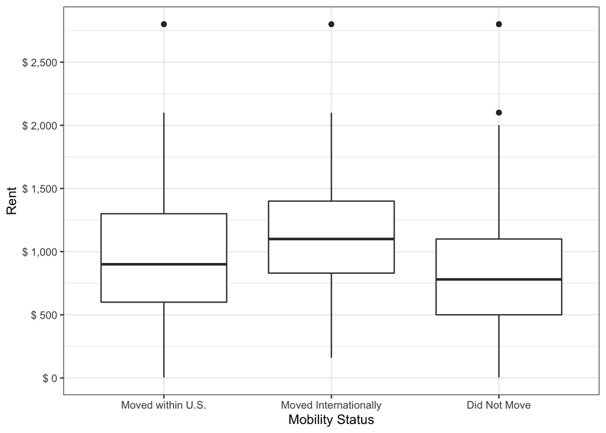

```r
ggplot(new_person_data, aes(x = MIG_label, y = RNTP)) +
  geom_boxplot() +
  theme_bw() +
  scale_x_discrete(name = "Mobility Status",
   labels = c("Moved within U.S.", "Moved Internationally", "Did Not Move")) +
  scale_y_continuous(name = "Rent",
                     breaks = seq(0, 4000, by = 500),
                     labels = paste("$",
                                    prettyNum(seq(0, 4000, by = 500),
                                              big.mark = ",")))
```

In this boxplot we can see differences in medians and interquartile ranges.

## Anova Mobility Status and Income

```r
anova <- aov(PINCP ~ MIG_label, data = new_person_data)

summary(anova)
```

```
##                Df         Sum Sq    Mean Sq F value  Pr(>F)
## MIG_label       2    15986136522 7993068261   4.945 0.00713 **
## Residuals   17074 27601018275375 1616552552
## ---
## Signif. codes:  0 '***' 0.001 '**' 0.01 '*' 0.05 '.' 0.1 ' ' 1
```

### Tukey’s Honestly Significant Difference - Mobility Status and Income

```r
differences <- TukeyHSD(anova)

as_tibble(cbind(pair = row.names(differences$MIG_label),
                differences$MIG_label))
```

```
## # A tibble: 3 x 5
##   pair                              diff       lwr        upr        `p adj`
##   <chr>                             <chr>      <chr>      <chr>      <chr>
## 1 No, outside US and Puerto Rico-N… -383.6585… -8208.583… 7441.2663… 0.99274515…
## 2 Yes, same house (nonmovers)-No, … -2200.787… -3853.128… -548.4468… 0.00511772…
## 3 Yes, same house (nonmovers)-No, … -1817.128… -9557.694… 5923.4363… 0.84635589…
```

### Plotting Mobility Status and Income

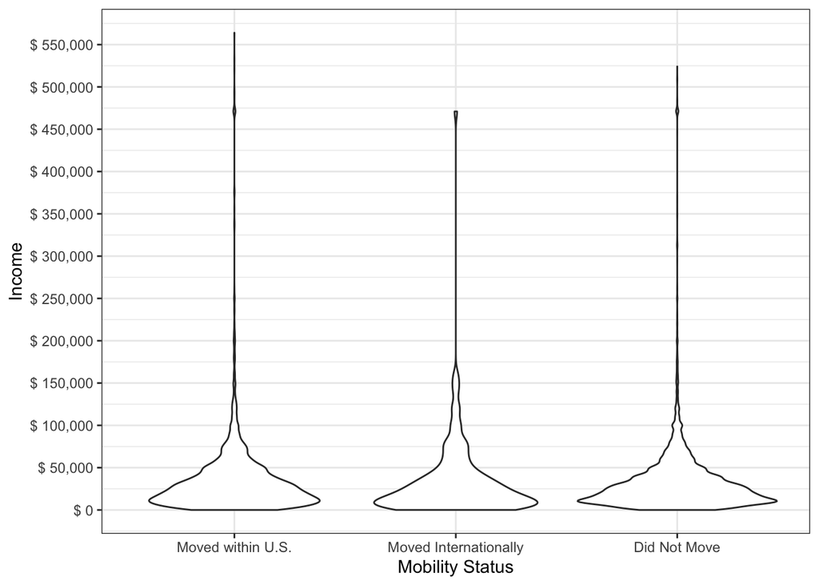

```r
ggplot(new_person_data, aes(x = MIG_label, y = PINCP)) +
  geom_violin() +
  theme_bw() +
  scale_x_discrete(name = "Mobility Status",
   labels = c("Moved within U.S.", "Moved Internationally", "Did Not Move")) +
  scale_y_continuous(name = "Income",
                     breaks = seq(0, 600000, by = 50000),
                     labels = paste("$",
                                    prettyNum(seq(0, 600000, by = 50000),
                                              big.mark = ",")))
```

## Anova Mobility Status and Household Size

```r
anova <- aov(NP ~ MIG_label, data = new_person_data)

summary(anova)
```

```
##                Df Sum Sq Mean Sq F value     Pr(>F)
## MIG_label       2     78   39.08   13.36 0.00000159 ***
## Residuals   17074  49941    2.92
## ---
## Signif. codes:  0 '***' 0.001 '**' 0.01 '*' 0.05 '.' 0.1 ' ' 1
```

### Tukey’s Honestly Significant Difference - Mobility Status and Household Size

```r
differences <- TukeyHSD(anova)

as_tibble(cbind(pair = row.names(differences$MIG_label),
                differences$MIG_label))
```

```
## # A tibble: 3 x 5
##   pair                            diff        lwr         upr       `p adj`
##   <chr>                           <chr>       <chr>       <chr>     <chr>
## 1 No, outside US and Puerto Rico… 0.24483496… -0.0880129… 0.577682… 0.196162265…
## 2 Yes, same house (nonmovers)-No… 0.15242392… 0.08213849… 0.222709… 0.000001154…
## 3 Yes, same house (nonmovers)-No… -0.0924110… -0.4216706… 0.236848… 0.787907221…
```

### Plotting Mobility Status and Household Size

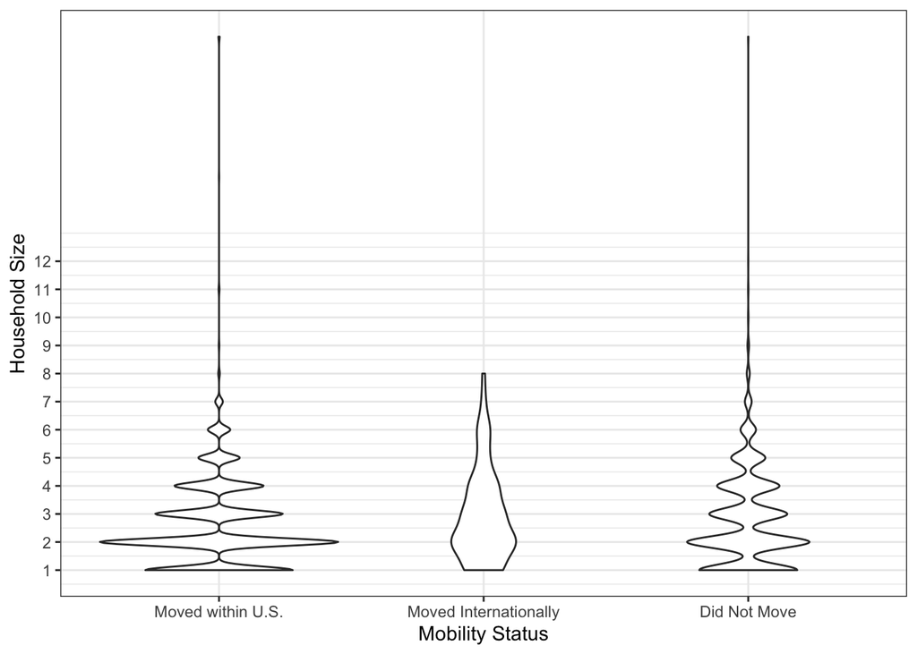

```r
ggplot(new_person_data, aes(x = MIG_label, y = NP)) +
  geom_violin() +
  theme_bw() +
  scale_x_discrete(name = "Mobility Status",
   labels = c("Moved within U.S.", "Moved Internationally", "Did Not Move")) +
  scale_y_continuous(name = "Household Size",
                     breaks = seq(1, 12, by = 1),
                     labels = paste(
                                    prettyNum(seq(1, 12, by = 1),
                                              big.mark = ",")))
```

# Two Categorial Variables - Mobility Status and Ethnicity

## Hispanic Ethnicity and Mobility Status

```r
chi_sq <- chisq.test(new_person_data$MIG_label, new_person_data$HISP_label ==
                       "Hispanic")

chi_sq
```

```
##
##  Pearson's Chi-squared test
##
## data:  new_person_data$MIG_label and new_person_data$HISP_label == "Hispanic"
## X-squared = 28.241, df = 2, p-value = 0.0000007372
```

In running a Chi-squared test, it appears that there is a statistically significant relationship between ethnicity and mobility status, both for Hispanics and non-Hispanics. However, I would like to better understand how to interpret the results.

Observed

```r
chi_sq$observed
```

```
##
## new_person_data$MIG_label                  FALSE  TRUE
##   No, different house in US or Puerto Rico  4034   359
##   No, outside US and Puerto Rico             125    25
##   Yes, same house (nonmovers)              11209  1325
```

Expected

```r
chi_sq$expected
```

```
##
## new_person_data$MIG_label                       FALSE       TRUE
##   No, different house in US or Puerto Rico  3953.3656  439.63442
##   No, outside US and Puerto Rico             134.9886   15.01142
##   Yes, same house (nonmovers)              11279.6458 1254.35416
```

## Non-Hispanic Ethnicity and Mobility Status

```r
chi_sq <- chisq.test(new_person_data$MIG_label, new_person_data$HISP_label ==
                       "Non Hispanic")

chi_sq
```

```
##
##  Pearson's Chi-squared test
##
## data:  new_person_data$MIG_label and new_person_data$HISP_label == "Non Hispanic"
## X-squared = 28.241, df = 2, p-value = 0.0000007372
```

There also appears to be a statistically significant relationship between the variables of non-Hispanic Ethnicity and mobility status.

Observed

```r
chi_sq$observed
```

```
##
## new_person_data$MIG_label                  FALSE  TRUE
##   No, different house in US or Puerto Rico   359  4034
##   No, outside US and Puerto Rico              25   125
##   Yes, same house (nonmovers)               1325 11209
```

Expected

```r
chi_sq$expected
```

```
##
## new_person_data$MIG_label                       FALSE       TRUE
##   No, different house in US or Puerto Rico  439.63442  3953.3656
##   No, outside US and Puerto Rico             15.01142   134.9886
##   Yes, same house (nonmovers)              1254.35416 11279.6458
```